# 動物實驗設計與研究方法

Week 02｜動物實驗倫理與 3Rs

陳敬元 Jing-Yuan Chen, DVM, PhD

jychen@niar.org.tw

國家實驗研究院國家生物模式中心

宜蘭大學生物技術與動物科學系

September 17, 2026

# 01｜從 paper 實例進入 3Rs

## 今天討論三個問題

1. 為什麼這個研究需要使用動物？
2. Replacement、Reduction、Refinement 分別要注意什麼？
3. 作者的研究設計與結果是否合理？還有帶出哪些倫理問題？

## 今天的節奏

1. 先用一個 paper 說明如何提出 3Rs 問題
2. 交換自己的 anchor paper 觀察
3. 用 3Rs 整理動物使用的理由與動物可能承受的影響
4. 用 harm-benefit analysis 連接科學效益與倫理判斷
5. 用一個簡化案例練習提出審查問題

這週來練習「問問題」！

## 從 paper 到 3Rs 問題

- 讀到一篇動物研究時，先看看研究設計方面：
  1. 這個問題是否必須在**活體動物身上觀察**？
     - 例如：生長、體溫調節、代謝、免疫反應、疾病進程或行為
  2. paper 哪一段說明作者為什麼使用動物？
  3. 哪些程序會造成主要的疼痛、不適、壓力或長期影響？
  4. 哪些資訊不足，讓我們還不能判斷 3Rs

## 參考 paper｜先看研究問題

[figure not shown]

## 參考 paper｜abstract 裡找出三個部分

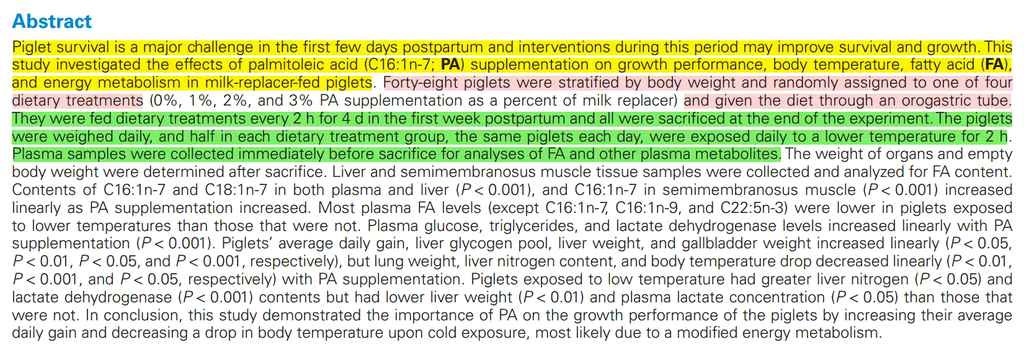

## 從重點標示到倫理問題

- 找出三部分標示後，進一步思考：
  - **Replacement**：這個問題有哪些部分無法由非動物方法回答？
  - **Reduction**：48 隻仔豬是否有足夠理由，不只是數量看起來多或少？
  - **Refinement**：管灌餵食、低溫暴露與終端採樣的疼痛、不適或壓力如何被降低？
  - **Scientific validity**：如果實驗設計無法可靠回答問題，動物使用就失去倫理基礎。

## 看到現實限制，轉成可以延伸思考的問題

- 新生仔豬體溫調節：哪些結果必須在活體仔豬身上觀察？
- 低溫暴露與終端採樣：哪些程序必要？哪些地方需要說明 refinement？
- 豬場田間試驗：現場無法完全控制時，作者如何補強紀錄與對照？

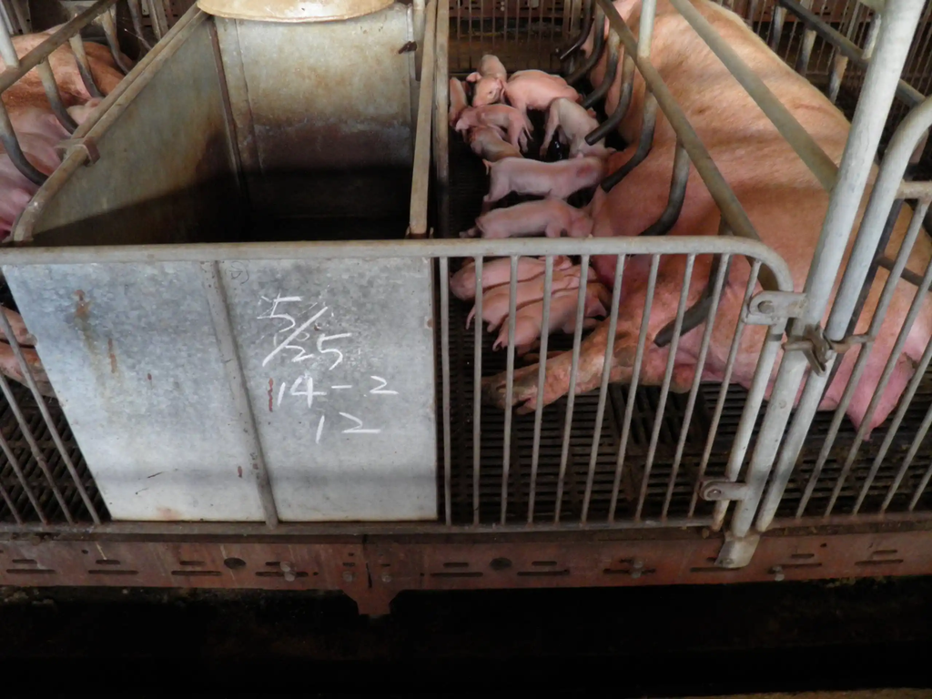

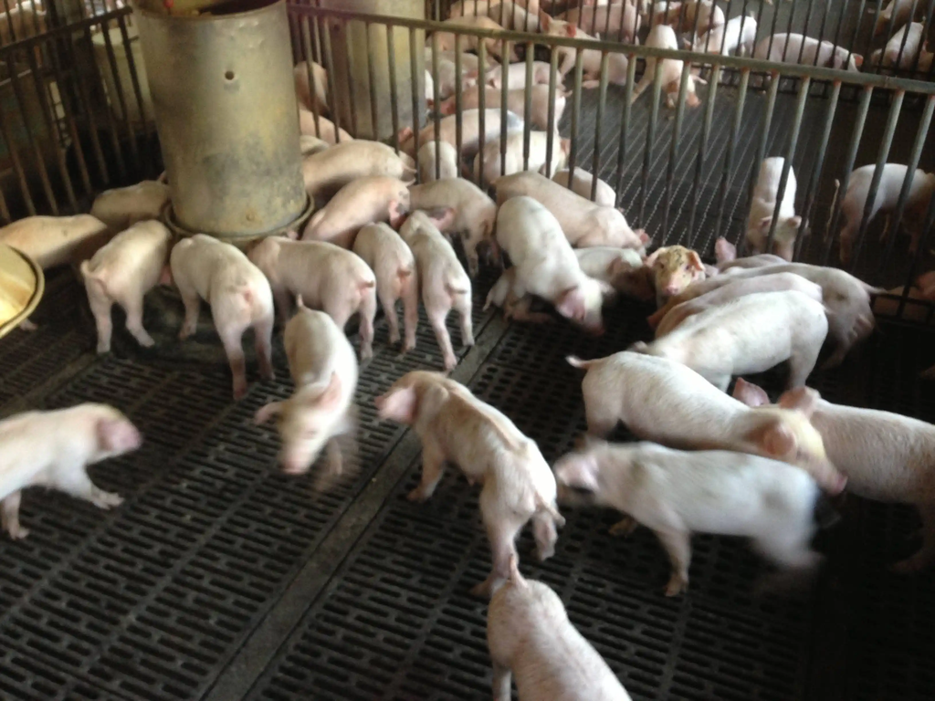

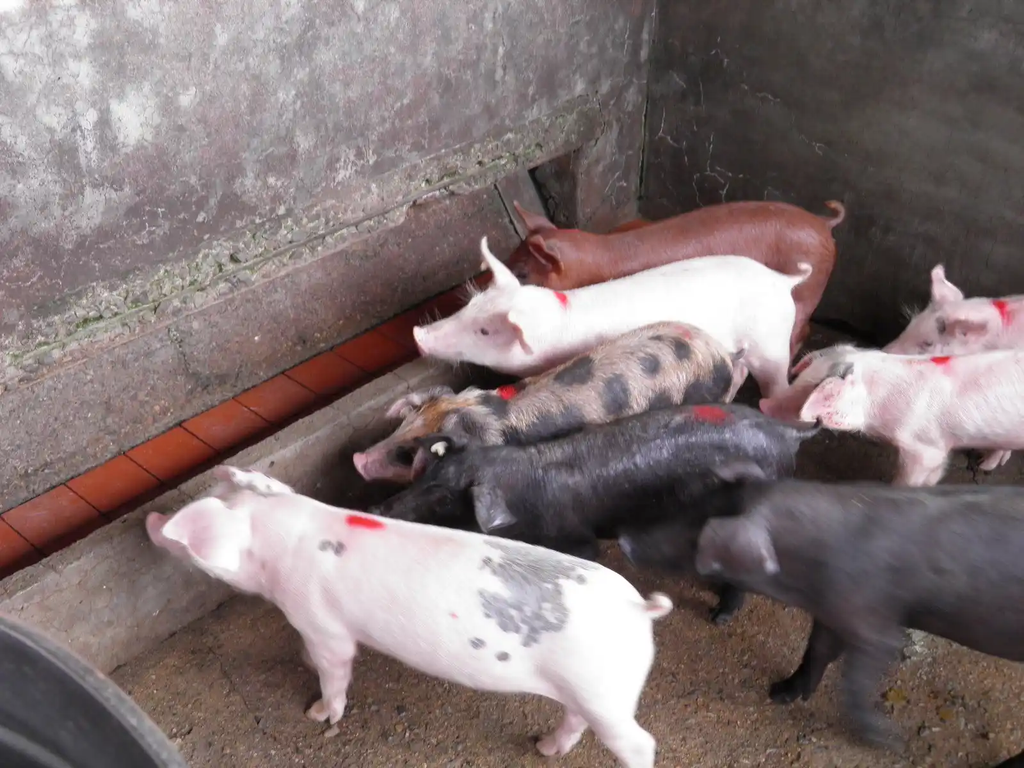

## 現實限制也是倫理判斷的一部分

- 動物實驗很少能達到完美的 3Rs，但仍需要持續檢查與精進
- 面對條件限制時，更要清楚說明：
  - 哪些限制真的存在？
  - 研究者嘗試了哪些替代或降低傷害的方法？
  - 動物仍需承受的疼痛、不適或壓力，是否有足夠的研究目的與可靠設計作為理由？

## 動物實驗不完美設計下的三種情境

| 情況 | 看到什麼 | 可以怎麼問 |
| --- | --- | --- |
| 合理限制 | 問題必須在活體動物身上觀察，且作者有說明原因 | 有哪些 refinement 可以降低疼痛、不適或壓力？ |
| 資訊不足 | paper 沒寫清楚程序、頻率、實驗終點或原因 | 需要作者補什麼資訊？ |
| 設計問題 | 動物承受明顯傷害或壓力，但研究問題、outcome 或分析無法支撐結論 | 動物使用是否還有足夠理由？ |

## 先從 anchor paper 開始

兩到三人一組，先各自花 1 分鐘整理想法，再交換以下三項觀察：

1. 這篇研究想回答什麼問題？
2. 為什麼作者需要使用動物？
3. 目前看到哪一項倫理或 3Rs 問題？

每人分享約 2 分鐘；聽的人從下一張提問卡參考提出問題。

## 提問卡

不知道要問什麼時，可以從這裡選一題：

1. 你是根據 paper 哪一段做這個判斷？
2. 如果不用活體動物，有沒有其他方法可以先回答一部分？
3. 哪一個程序最可能造成疼痛、不適或壓力？
4. paper 還缺少哪些資訊，讓你無法判斷？
5. 如果這個設計回答不了研究問題，動物使用的理由會不會變弱？

## 動物倫理從研究問題開始

- **研究目的**：這個問題為什麼值得回答？
- **動物使用的必要性**：哪些資訊必須由活體動物取得？
- **動物可能承受的影響**：動物可能承受哪些疼痛 (pain)、不適或壓力 (distress)，或長期傷害 (lasting harm)？
- **科學可行性**：目前的設計是否有機會回答研究問題？

因此，動物使用的必要性、動物可能承受的影響與科學可行性需要一起評估。

## 3Rs 在現今實驗設計中的角色

[figure not shown]

3Rs 不只是倫理精神，也是持續檢查研究設計的方式。

## 讀 paper 時要找的 3Rs 線索

| 原則與現今定位 | 讀 paper 時先找什麼 | 待釐清的問題 |
| --- | --- | --- |
| **Replacement** *(替代方法增加了，先確認活體必要性)* | 是否真的需要在活體動物身上觀察？ | 研究問題中，有哪些部分可以先用人類來源檢體、cell model、computer model 或既有資料回答？ |
| **Reduction** *(設計與分析決定隻數是否有意義)* | 動物數量與分組是否有估算依據？ | 作者是否說明 primary outcome、分組邏輯、樣本數依據，或每隻動物能提供哪些資料？ |
| **Refinement** *(飼養與監測直接影響資料品質)* | 哪些程序可能造成疼痛、不適、壓力或長期影響？ | 作者是否說明 housing、handling、anaesthesia、analgesia、training、monitoring 或停止條件？ |

[figure not shown]

Image source: [FC3R 3Rs pictograms](https://www.fc3r.com/en/educational-materials.php)

## 替代方法從哪裡查

[output not shown]

## SMAFIRA 範例結果

[figure not shown]

- 相似文獻主要落在哪些 experimental model？
- non-animal filters 是否有可篩選結果？
- 這個結果能說明什麼，又不能說明什麼？

Search example: [SMAFIRA](https://smafira.bf3r.de/) using Feyera et al. 2023, PMID [37935407](https://pubmed.ncbi.nlm.nih.gov/37935407/)

## Replacement｜先確認活體動物是否必要

- 是否已有 cell、tissue、organoid、computer model 或既有資料可以回答問題？
- 能否先用非動物方法篩選，再將少數必要問題帶入動物研究？
- 若仍需要活體動物，哪一個結果必須在動物身上觀察？

**先確認這個問題是否必須在活體動物身上觀察，再決定是否需要使用動物。**

## Reduction｜動物數要能回答研究問題

- 動物數量應有明確的估算依據
- 分組、主要結果與變異控制會影響需要的動物數
- 共用適當的 control、資料或組織，有時可以避免重複使用動物
- 數量過少而無法回答問題，同樣可能浪費動物

**Reduction：使用足以回答問題、但不超過必要範圍的動物數。**

## Refinement｜降低研究過程造成的疼痛與不適

- 動物來源、運輸、適應 (acclimation) 與飼養管理 (housing)
- 操作與保定 (handling & restraint)、採樣 (sampling)、麻醉與止痛 (anesthesia & analgesia)、適應期 (acclimation)
- 監測頻率、人道終點 (humane endpoints) 與異常處置
- 人員訓練、程序可行性與實際紀錄

**Refinement 從動物進場前開始，持續到研究結束。**

## Refinement 也影響資料能不能解讀

- 動物承受疼痛、不適、壓力或長期影響時，

可能改變：

- 行為表現
- 生理狀態
- 免疫反應
- 實驗變異

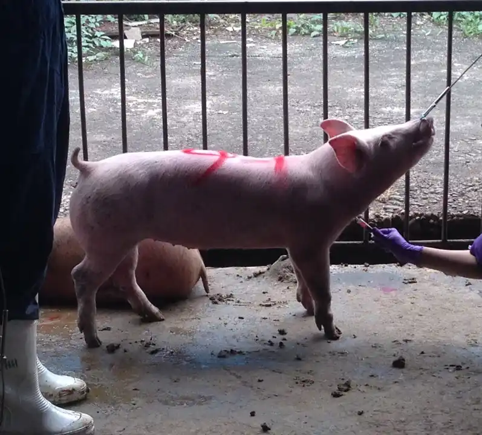

- 降低動物的疼痛、不適與壓力不只是動物福祉的要求，也會影響資料的可信度 (reliability)與可重複性 (repeatability)。

## 例子｜連續採血可以怎麼 refinement？

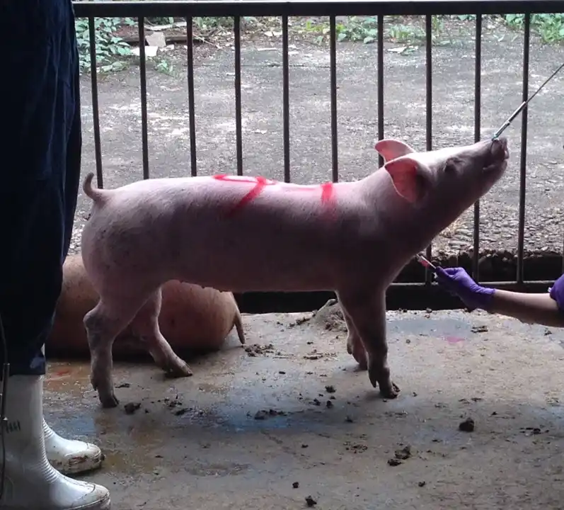

- 為什麼 PK study 需要連續的血中藥物濃度資料？
- 保定與採樣可能讓動物承受哪些影響？
- 哪些 refinement 可以降低疼痛、不適、壓力或實驗變異？

## 回到 anchor paper

現在各寫下一句：

1. **Replacement**：作者為什麼仍需要活體動物？
2. **Reduction**：文章提供了什麼動物數量估算依據？
3. **Refinement**：哪一項程序或監測最可能造成疼痛、不適或壓力？

無法從 paper 找到的資訊，也是一項閱讀結果。

## Paper 沒寫，也是一項閱讀結果

閱讀 paper 時，可以把資訊分成三類：

| 類別 | paper 中對應的資料 |
| --- | --- |
| 有明確寫出 | 直接引用 methods、results 或 supplementary information |
| 有線索但不完整 | 寫成需要確認的問題 |
| 完全沒有交代 | 標示為 unknown，不自行替作者補答案 |

## 第一節先記住三件事

- 研究問題要能說明為什麼需要使用動物
- 3Rs 會影響方法、動物數量、操作程序與監測方式
- paper 沒寫清楚時，先記下需要作者說明的地方

動物實驗設計需要把「為什麼做」和「怎麼做」說清楚。

# 02｜研究價值與動物承受的影響

## 傷害–效益評估 (Harm–benefit analysis) 在比較什麼？

### 可能造成的影響

- 疼痛、不適與壓力
- 程序強度與持續時間
- 累積影響與可能的長期傷害 (lasting harm)

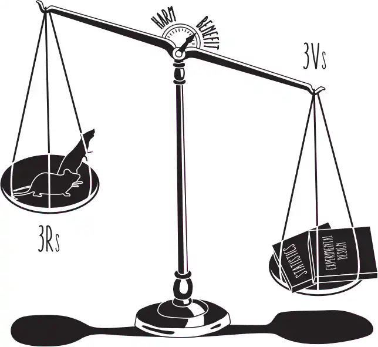

### 預期效益

- 問題的重要性
- 可能增加哪些知識
- 研究設計產生可信結果的可能性

**研究的預期效益，需要由清楚的研究問題與可靠的設計支持。**

**「未來可能有幫助」？**

## 研究設計也影響倫理判斷

如果研究設計無法產生可解讀的資料：

- 動物仍然承受研究程序造成的疼痛、不適或壓力
- bias 或 confounding 可能使結果無法判斷
- 不清楚的 outcome 可能讓主要問題沒有答案
- 不完整的紀錄可能使結果無法被檢查或重複利用

**設計良好不保證得到預期結果，但應降低可以事前避免的失敗。**

## 案例背景｜飼料添加物為什麼需要評估？

飼料添加物會影響動物的生長、健康、飼料利用或產品品質。

在台灣，飼料添加物屬於公告管理的品目，常見類型包括：

- 微生物、益生素、酵素
- 胺基酸、維生素、礦物質
- 植物萃取物或天然有效成分
- 保存、品質或製程相關添加物

**因此，研究者需要說明：效果、安全性、使用對象與劑量是否合理。**

## 案例討論｜一項飼料添加物試驗

研究者想了解一種新添加物是否改善離乳仔豬的生長表現。

計畫書目前大致如下：

- 使用 40 頭仔豬，分成添加物組與對照組
- 每週測量體重與採血，連續四週
- 主要理由：前一篇 paper 也使用 40 頭
- 預期效益：若有效，可能改善離乳後生長表現

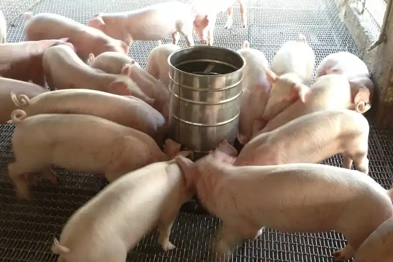

## 案例資料｜目前計畫書提供的資訊

| 項目 | 研究者目前寫法 | 可先注意的問題 |
| --- | --- | --- |
| 研究目的 | 測試新添加物是否改善離乳仔豬生長 | 改善生長主要看哪一個觀察指標 (primary outcome)？ |
| 動物與分組 | 40 頭仔豬，添加物組與對照組 | 40 頭的依據是否只來自前人文獻？ |
| 測量 | 每週體重、每週採血，連續四週 | 採血目的、頻率與總採血量是否說明？ |
| 動物照護 | 一般飼養管理 | acclimation、監測頻率與異常處置是否足夠？ |
| 結果判讀 | 比較兩組最後生長表現 | 若中途生病或退出，資料如何處理？ |

## 舉例一下

從一個不清楚的地方開始：

> 計畫書沒有指定主要的觀察指標 (primary outcome)？

可以變成一個問題：

> 本研究主要想判斷哪一個結果？體重增加、飼料效率、血液指標，還是疾病發生率？

## 案例討論流程

這個案例先不要求完整改良設計。每組只完成一個問題：

1. 選出一個最需要先釐清的地方
2. 看它比較接近 Replacement、Reduction、Refinement，或研究設計問題
3. 寫成一句可以請研究者說明的問題

## 用 3Rs 重新檢查這個案例

兩到三人一組，先從下面挑一個問題：

1. **Replacement**：哪些問題必須在活體仔豬中回答？
2. **Reduction**：40 頭的理由是否足夠？還需要哪些資訊？
3. **Refinement**：每週採血是否必要？如何降低疼痛、不適或壓力？
4. **研究設計**：沒有 primary outcome，會造成什麼判讀問題？
5. **Monitoring**：如何處理生病、退出與 humane endpoint？

## 審查問題如何促成設計修正

這個案例至少需要補充：

- 明確的研究目的與 primary outcome
- 活體動物及重複採血的必要性
- 動物數的設計與分析依據
- 動物監測、退出條件與 humane endpoints
- 預期效益與動物可能承受影響的相對關係

**好的倫理問題，會讓研究設計在開始前變得更清楚。**

## 今天的三個核心觀念

1. **動物使用要有必要性**：研究問題應說明為什麼必須在活體動物身上觀察。
2. **3Rs 改變研究設計**：不只是申請書中的三個欄位。
3. **研究設計要能支持預期效益**：否則動物承受疼痛、不適或壓力後，仍可能無法回答研究問題。

## 下週課前｜再看一下你的 anchor paper

配合 Week 3「動物研究的應用與限制」，請先標記：

1. 這個 animal model 代表哪一個研究對象或生物過程？
2. 它可以回答研究問題的哪一部分？
3. 哪一項差異或研究條件，可能限制結果的解釋範圍？

不需要準備完整報告；在 paper 上留下三個註記即可。

## 本週參考資料與延伸閱讀

- NC3Rs. [The 3Rs](https://nc3rs.org.uk/who-we-are/3rs)
- Lauwereyns *et al.* (2024). [Toward a common interpretation of the 3Rs principles in animal research](https://doi.org/10.1038/s41684-024-01476-2)
- Wurbel (2017). [More than 3Rs: the importance of scientific validity for harm-benefit analysis](https://doi.org/10.1038/laban.1220)

### 本週先讀 NC3Rs 的 3Rs 定義；其他資料依需要延伸